# PSM oder nicht PSM

Martin Schaffhauser

2022-11-12

# PSM wofür?

Goldstandard für den Vergleich einer Variable ist die randomisiserte kontrollierte Studie (RCT). Kovariaten (Variablen neben der Variable im Hauptinteresse) werden hier durch Zufall auf die 2 (oder mehr) zu vergleichenden Gruppen verteilt und man kann davon ausgehen, dass das einzige wodurch sich die 2 Gruppen unterscheiden die zu untersuchende Variable ist bzw. Kovariaten keinen Einfluss auf die Zuordnung zu einer Gruppe haben (weil eben randomisiert).

In Observationsstudien ist das anders - ihr sammelt Daten aus stattgehabtem klinischem Alltag, wo ihr die Entscheidung zur Behandlung (ja/nein) nicht per Zufall sondern per Indikation trefft. Das können dann einige Kovariaten sein, die zur Behandlungsentscheidung geführt haben - damit unterscheiden sich natürlich dann die Gruppe mit Behandlung und die ohne Behandlung in diesen Variablen voneinander - es liegt also ein systematischer Bias vor.

Hier kommt propensity score matching (PSM) ins Spiel - wobei im Folgenden dann gezeigt wird, dass die Diskussion PSM vs. multiple Regression nicht entschieden ist. Beim PSM wird ein propensity score (PS) aus Variablen errechnet, von denen man weiß bzw. vermutet, dass sie mit der Gruppierungsvariable (zB Behandlung ja/nein) kausal assoziert sind. Der PS ist also ein einzelner Score, der aus mehreren Variablen die Wahrscheinlichkeit der Gruppenzuordnung angibt - also mehrere Dimensionen auf eine einzelnte reduziert.

Nachdem man für den gesamten Observationsdatensatz den PS für alle Patienten berechnet hat, kann man jetzt Patienten (zB behandelte und nicht behandelte) mit gleichen/ähnlichen PS nach verschiedenen Algorithmen miteinander matchen und in Folge die Gruppierungsvariable auf ihren Effekt auf eine Outcomevariable untersuchen; also zB schauen ob die Behandlung einen Effekt auf einen gewählten Outcomeparameter hat.

## Datensatzsimulation

Um zu zeigen, wie der Ablauf eines PSM ist und auch die Ähnlichkeit zur multiplen Regression herauszuarbeiten, habe ich folgendes (etwas dümmliches, weil fehlende Kreativität) toy example simuliert. Es wird ein Datensatz generiert, dessen Eigenschaft wir ganz genau kennen, so können wir die Methodik prüfen. *Bei einem klinisch erhobenen Datensatz wissen wir die Populationsparameter natürlich nicht.*

**Kurze Beschreibung vom toy example:**

Für die PS Berechnung bauen wir einen bekannten Zusammenhang zwischen den Kovariaten Alter und Geschlecht in den PS für Gruppenzuordnung ein (für das Alter einen quadratischen Zusammenhang: Junge und Alte bekommen eher keine BP Medikation und für Männer eine höhere Wahrscheinlichkeit eine Medikation zu bekommen - alles ein toy example als proof of principle - macht natürlich keinen echten Sinn).

Außerdem simulieren wir einen Effekt von RRMed, Alter, Geschlecht und Beruf auf den Blutdruck (BP):

$$BP = 80 + 0.5 * Alter + 15 * Geschlecht + 10 * Chirurg + 20 *
Statistiker + Internist - 40 * RRMed + error$$

(wenn ihr auf den Code-Button clickt, könnt ihr den jeweiligen Code ausklappen bei Interesse)

```r
# for random generation
set.seed(2020)

# 0 = w, 400 w, 600 m
Geschlecht <- rep (0:1, c(400,600))
# normalverteiltes Alter, nur positive (abs())
Alter <- round(abs(rnorm(1000, mean=45, sd=15)))
# another categorical variable
Beruf <- rep(c("Chirurg", "Internist", "Statistiker"), c(300,300,400))

# known PS
# RR-Medikation ja/nein hat in diesem Beispiel eine quadratische Relation mit
# Alter sowie eine höhere Wahrscheinlichkeit für Geschlecht = m\
# (x-μ)/σ is z score https://www.simplypsychology.org/z-score.html
z <- (Alter - 45) / 15 - (Alter - 45) ^ 2 / 100 + 2 * Geschlecht
# plot(z %>% sort())
# https://de.wikipedia.org/wiki/Logit,
# https://search.r-project.org/CRAN/refmans/LaplacesDemon/html/logit.html,
# inverse logit transformation - transform vector to probabilities
### example
# library("SciViews")
# a <- c(1,4,2,6,4,8,2,5,9,4) %>% sort()
# logit <- exp(a) / (1 + exp(a)) # transform vector to probabilities
# ln(logit/(1-logit)) %>% sort() # transform probabilities to vector again
# plot(a)
# plot(logit)
truePS <- exp(z) / (1+exp(z))
# plot(tps %>% sort())
# plotting the relationship
# plot(Alter, truePS)
# now we have a vector of propensity scores that are related to Alter and
# Geschlecht --> draw from uniform distribution randomly 1000 times --> if the
# value in the vector is smaller than the value in the truePS vector treatment
# is going to be 1 and the other way round
RRMed <- as.numeric(runif(1000) < truePS)

# creating a data generation process for the outcome measure BP
# https://www.youtube.com/watch?v=fDFyG_q2xQs
# https://stats.oarc.ucla.edu/r/modules/coding-for-categorical-variables-in-regression-models/
error <- rnorm(1000, 0, 5) # error term

BP <- 80 +
  0.5 * Alter +
  15 * Geschlecht +
  10 * I(Beruf == "Chirurg") +
  20 * I(Beruf == "Statistiker") +
  I(Beruf == "Internist") -
  40 * RRMed +
  error

Geschlecht <- as.factor(Geschlecht)
Beruf <- as.factor(Beruf)
RRMed <- as.factor(RRMed)

data <- data.frame(BP,
                   RRMed,
                   Alter,
                   Geschlecht,
                   Beruf,
                   truePS)

### Add Missingness MCAR
# x.Age.mask <- rbinom (1000, 1, 0.2) # Missing completely at random - delete some age values for MCAR
# data <- data.frame (x.Age, x.Age.mask, x.Gender, Smoke, CVD, bp, tps)
# data <- data %>%
#   mutate(Age_missing = case_when(
#     x.Age.mask == 1 ~ NA_character_,
#     TRUE ~ as.character(x.Age)
#   )) %>%
#   mutate(Age_missing = as.numeric(Age_missing)) %>%
#   select(-x.Age.mask) %>%
#   rename(Age_all = x.Age,
#          Gender = x.Gender,
#          true_PS = tps) %>%
#   relocate(Age_missing, .after = Age_all)
```

In diesem Plot wird illustriert, wie der echte (also bekannte, weil simulierte) PS mit dem Alter und dem Geschlecht zusammen hängt - Männer sind die Kurve mit der höheren Wahrscheinlichkeit.

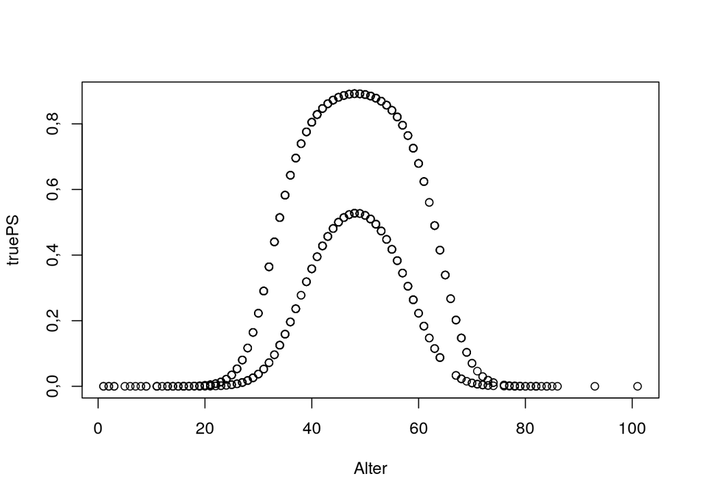

```r
plot(Alter, truePS)
```

## PS Estimation

Nun soll der propensity score - also die Wahrscheinlichkeit (0 bis 1) aufgrund von gewählten Kovariaten der Gruppe mit Medikation vs der ohne Medikation zugeordnet zu werden - geschätzt werden. Es müssen hier klinisches Wissen bzw. Vermutungen, die eine Assoziation nahelegen, berücksichtigt werden.

Zu Schätzung gibt es verschiedene Methoden. Meistens wird hier eine logistische Regression als Modell verwendet. Man kann das auch über Neural Networks machen, aber das sind dann “Blackboxes” deren Regeln man nicht kennt. Außerdem kenne ich mich damit nicht aus.

```r
# Alter linear
m.out1 <- matchit(RRMed ~
                   Alter +
                   Geschlecht,
                 data = data,
                 distance = 'logit')

# Alter quadratisch
m.out2 <- matchit(RRMed ~
                   poly(Alter, 2) +
                   Geschlecht,
                 data = data,
                 distance = 'logit')
```

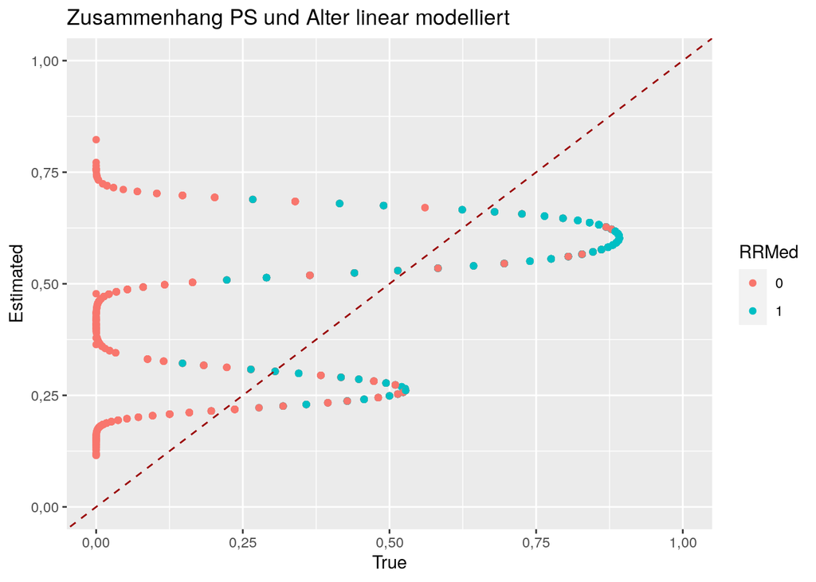

```r
estimatedPS <- m.out1$distance # Estimated PS
truePS <- data$truePS # Because we only use complete cases
RRMed <- data$RRMed

df <- data.frame(True = truePS,
                 Estimated = estimatedPS,
                 RRMed = RRMed)

ggplot(df, aes(x = True, y = Estimated, colour = RRMed)) +
  geom_point() +
  geom_abline(intercept = 0,
              slope = 1,
              colour = "#990000",
              linetype = "dashed") +
  expand_limits(x = c(0,1),
                y = c(0,1)) +
  ggtitle("Zusammenhang PS und Alter linear modelliert")
```

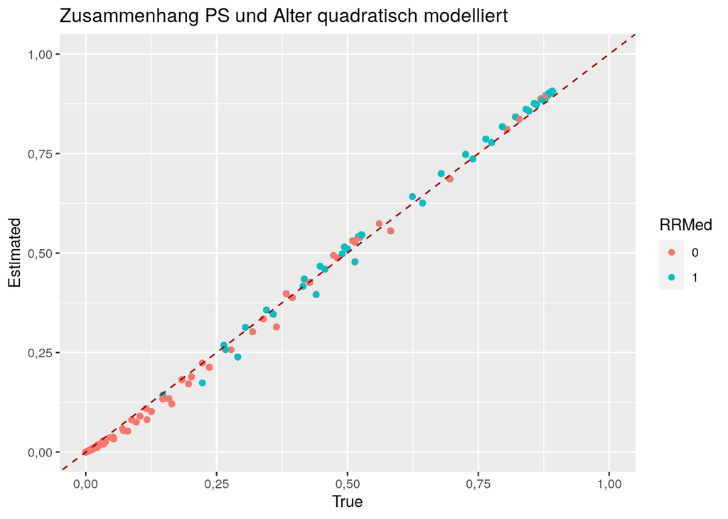

```r
estimatedPS <- m.out2$distance # Estimated PS
truePS <- data$truePS # Because we only use complete cases
RRMed <- data$RRMed

df <- data.frame(True = truePS,
                 Estimated = estimatedPS,
                 RRMed = RRMed)

ggplot(df, aes(x = True, y = Estimated, colour = RRMed)) +
  geom_point() +
  geom_abline(intercept = 0,
              slope = 1,
              colour = "#990000",
              linetype = "dashed") +
  expand_limits(x = c(0,1),
                y = c(0,1)) +
  ggtitle("Zusammenhang PS und Alter quadratisch modelliert")
```

Hier wird ersichtlich, dass die PS Schätzung nicht trivial ist. Im ersten Plot entsprechen die geschätzten PS überhaupt nicht den tatsächlichen PS. Erst im zweiten Plot wo der quadratische Zusammenhang aus Alter und RRMed berücksichtigt wird sieht man, dass die geschätzten den echten PS entsprechen.

Wir wissen hier in diesem Beispiel ja genau, wie der PS zustande kommt, können ihn also exakt schätzen. Weiß man das allerdings nicht, so kann man hier natürlich wild daneben liegen und falsche Scores berechnen, womit ein Match dann natürlich nicht so gut funktioniert bzw. der Bias nicht hinaus gearbeitet wird.

## Matching

Mit einem Modell, das die PS perfekt schätzt (weil uns die Relationen aus Kovariaten und PS ja bekannt sind) geht es nun zum Match. Ziel ist es die jeweilige Abstände zwischen den PS von Matches zu minimieren und auch für den gesamten Datensatz eine möglichst geringe mittlere Abweichung zwischen den PS zu erreichen. Matches können 1:1 bis 1:n zwischen treatment und control passieren.

Hier gibt es diverse Algorithmen.

Nearest neighbor matching ist zB ein Alogrithmus der sich einfach durch die Liste an Patienten geht (in gegebener Reihenfolge) und sich den jeweils besten Match sucht. Kann natürlich dazu führen, dass insgesamt nicht der beste Match passiert, weil immer nur ein Match pro Iteration beachtet wird (greedy algorithm).

Ein anderer Algorithmus ist genetic matching, den ich mir noch nicht so genau angeschaut habe, der aber gute Ergebnisse bringt.

Parameter, die die Güte des Match beurteilen sind SMD (standardized mean difference) und VR (variance ratio) - SMD sollte so nah wie möglich an 0 sein. Cutoffs aus der Literatur sind zB 0.1 SMD (Stuart, Lee, and Leacy (2013))

Hier ein Beispiel mit nearest neighbor matching. Es werden 1:1 Fall und Kontroll gematcht und pro Iteration jeweils der beste Match, also kleinste Distanz zwischen den PS gewählt. PS wurde hier 100% richtig geschätzt (Alter quadratisch + Geschlecht):

```r
m.out.nn <- matchit(RRMed ~
                   poly(Alter, 2) +
                   Geschlecht,
                 data = data,
                 distance="logit",
                 method="nearest",
                 m.order = "largest",
                 caliper = 0.01,
                 replace=FALSE)

bal.tab(m.out.nn, m.threshold = 0.1, un = TRUE)
```

```
## Balance Measures
##                      Type Diff.Un Diff.Adj    M.Threshold
## distance         Distance  2,1459   0,0011 Balanced, <0,1
## poly(Alter, 2)_1  Contin.  0,5501   0,0763 Balanced, <0,1
## poly(Alter, 2)_2  Contin. -3,7867   0,0466 Balanced, <0,1
## Geschlecht         Binary  0,3207   0,0000 Balanced, <0,1
##
## Balance tally for mean differences
##                    count
## Balanced, <0,1         4
## Not Balanced, >0,1     0
##
## Variable with the greatest mean difference
##          Variable Diff.Adj    M.Threshold
##  poly(Alter, 2)_1   0,0763 Balanced, <0,1
##
## Sample sizes
##           Control Treated
## All           549     451
## Matched       179     179
## Unmatched     370     272
```

Hier sieht man, dass für ausreichend nahe Matches (SMD 0.1 als cutoff) nur 179 Fälle und 179 Kontrollen gematcht werden konnten. Hier ist die Retention also nur bei rund 36%.

Hier nochmal ein Match mit genetic matching (1:1):

```r
m.out.genetic <- matchit(RRMed ~
                   poly(Alter, 2) +
                   Geschlecht,
                 data = data,
                 distance = 'logit',
                 method = 'genetic',
                 pop.size = 250,
                 caliper = 0.01,
                 replace = F)
bal.tab(m.out.genetic, m.threshold = 0.1) # SMD - standardized mean difference
```

```
## Balance Measures
##                      Type Diff.Adj    M.Threshold
## distance         Distance   0,0011 Balanced, <0,1
## poly(Alter, 2)_1  Contin.   0,0763 Balanced, <0,1
## poly(Alter, 2)_2  Contin.   0,0466 Balanced, <0,1
## Geschlecht         Binary   0,0000 Balanced, <0,1
##
## Balance tally for mean differences
##                    count
## Balanced, <0,1         4
## Not Balanced, >0,1     0
##
## Variable with the greatest mean difference
##          Variable Diff.Adj    M.Threshold
##  poly(Alter, 2)_1   0,0763 Balanced, <0,1
##
## Sample sizes
##           Control Treated
## All           549     451
## Matched       179     179
## Unmatched     370     272
```

Gleiche Ergebnisse.

## Analyse und Vergleich mit multipler Regression

t Test bzw. simple lineare Regression mit binärer Gruppierungsvariable RRMed (in diesem Fall ist das mit t Test äquivalent; gematchte Daten aus nearest neighbor matching):

```r
matched_data <- match.data(m.out.nn)

t.test(BP ~ RRMed, matched_data, var.equal = T)
```

```
##
##  Two Sample t-test
##
## data:  BP by RRMed
## t = 33,272, df = 356, p-value < 0,00000000000000022
## alternative hypothesis: true difference in means between group 0 and group 1 is not equal to 0
## 95 percent confidence interval:
##  40,04025 45,07097
## sample estimates:
## mean in group 0 mean in group 1
##        121,4613         78,9057
```

```r
lm(BP ~
     RRMed,
   data = matched_data,
   weights=weights) %>%
  summary()
```

```
##
## Call:
## lm(formula = BP ~ RRMed, data = matched_data, weights = weights)
##
## Residuals:
##     Min      1Q  Median      3Q     Max
## -27,769  -9,065  -1,494   7,811  32,163
##
## Coefficients:
##             Estimate Std. Error t value            Pr(>|t|)
## (Intercept) 121,4613     0,9044  134,30 <0,0000000000000002
## RRMed1      -42,5556     1,2790  -33,27 <0,0000000000000002
##
## (Intercept) ***
## RRMed1      ***
## ---
## Signif. codes:
## 0 '***' 0,001 '**' 0,01 '*' 0,05 '.' 0,1 ' ' 1
##
## Residual standard error: 12,1 on 356 degrees of freedom
## Multiple R-squared:  0,7567, Adjusted R-squared:  0,756
## F-statistic:  1107 on 1 and 356 DF,  p-value: < 0,00000000000000022
```

Der Effekt der RRMedikation ist 42,5556 mmHg - t Test (121,4613 - 78,9057 = 42,5556) bzw. Regression (Koeffizient RRMed1 = 42,5556).

Jetzt hier zum Vergleich eine multiple Regression, die für die Kovariaten Alter und Geschlecht kontrolliert. Die also sehr ähnliche Ergebnisse wie ein zB ein t Test nach einem Match basierend auf einem PS der aus diesen Variablen errechnet wurde bringen sollte. Der Vorteil von der multiplen Regression ist hier allerdings, dass hier der gesamte Datensatz, also alle 1000 Patienten, berücksichtigt werden.

```r
lm(BP ~
     RRMed +
     Alter +
     Geschlecht,
   data = data) %>%
  summary()
```

```
##
## Call:
## lm(formula = BP ~ RRMed + Alter + Geschlecht, data = data)
##
## Residuals:
##     Min      1Q  Median      3Q     Max
## -25,421  -6,167   1,587   6,592  21,375
##
## Coefficients:
##              Estimate Std. Error t value
## (Intercept)  87,56521    0,92947   94,21
## RRMed1      -40,74019    0,60945  -66,85
## Alter         0,50376    0,01848   27,26
## Geschlecht1  20,97025    0,61275   34,22
##                        Pr(>|t|)
## (Intercept) <0,0000000000000002 ***
## RRMed1      <0,0000000000000002 ***
## Alter       <0,0000000000000002 ***
## Geschlecht1 <0,0000000000000002 ***
## ---
## Signif. codes:
## 0 '***' 0,001 '**' 0,01 '*' 0,05 '.' 0,1 ' ' 1
##
## Residual standard error: 8,967 on 996 degrees of freedom
## Multiple R-squared:  0,8324, Adjusted R-squared:  0,8319
## F-statistic:  1649 on 3 and 996 DF,  p-value: < 0,00000000000000022
```

Der Effekt von RRMed ist hier sehr ähnlich: 40,74019 wie aus dem gematchten Datensatz mit 358 Patienten (42,5556). Hier lässt sich jetzt diskutieren, welches Ergebnis “richtiger” ist. In der multiplen Regression werden 1000 Patienten verwendet, und tragen sicherlich zu dem etwas anderen Ergebnis bei. Im gematchten Datensatz werden nur 358 Patienten berücksichtigt und für den Bias aus Alter und Geschlecht wurde mittels PSM kontrolliert. Hier ist allerdigs der PS 100% richtig (weil simuliert), was mit einer echten Population nicht möglich ist.

Man kann auch einen “doubly robust” approach wählen und nach PSM die Kovariaten nochmals in eine Regressionsanalyse nehmen (Details muss ich mir erst anlesen).

Zur Erinnerung die Gleichung für Blutdruck:
$$BP = 80 + 0.5 * Alter + 15 * Geschlecht + 10 * Chirurg + 20 *
Statistiker + Internist - 40 * RRMed + error$$

```r
# matched data set
lm(BP ~
   RRMed +
   Alter +
   Geschlecht +
   Beruf,
 data = matched_data,
 weights = weights) %>%
  summary()
```

```
##
## Call:
## lm(formula = BP ~ RRMed + Alter + Geschlecht + Beruf, data = matched_data,
##     weights = weights)
##
## Residuals:
##      Min       1Q   Median       3Q      Max
## -13,6633  -3,4366  -0,2788   3,5424  18,3317
##
## Coefficients:
##                   Estimate Std. Error t value
## (Intercept)       88,43746    1,56561  56,487
## RRMed1           -40,57321    0,54602 -74,307
## Alter              0,53492    0,03005  17,799
## Geschlecht1       15,19333    1,06431  14,275
## BerufInternist    -9,37995    1,03941  -9,024
## BerufStatistiker   9,42629    1,27243   7,408
##                              Pr(>|t|)
## (Intercept)      < 0,0000000000000002 ***
## RRMed1           < 0,0000000000000002 ***
## Alter            < 0,0000000000000002 ***
## Geschlecht1      < 0,0000000000000002 ***
## BerufInternist   < 0,0000000000000002 ***
## BerufStatistiker    0,000000000000958 ***
## ---
## Signif. codes:
## 0 '***' 0,001 '**' 0,01 '*' 0,05 '.' 0,1 ' ' 1
##
## Residual standard error: 5,1 on 352 degrees of freedom
## Multiple R-squared:  0,9573, Adjusted R-squared:  0,9567
## F-statistic:  1577 on 5 and 352 DF,  p-value: < 0,00000000000000022
```

```r
# whole dataset
  lm(BP ~
     RRMed +
     Alter +
     Geschlecht +
     Beruf,
   data = data) %>%
    summary()
```

```
##
## Call:
## lm(formula = BP ~ RRMed + Alter + Geschlecht + Beruf, data = data)
##
## Residuals:
##      Min       1Q   Median       3Q      Max
## -13,9098  -3,1565  -0,0912   3,2645  18,9631
##
## Coefficients:
##                   Estimate Std. Error t value
## (Intercept)       90,38157    0,53395  169,27
## RRMed1           -40,23052    0,33849 -118,85
## Alter              0,49151    0,01026   47,88
## Geschlecht1       15,27176    0,62056   24,61
## BerufInternist    -9,59824    0,57487  -16,70
## BerufStatistiker   9,49799    0,71878   13,21
##                             Pr(>|t|)
## (Intercept)      <0,0000000000000002 ***
## RRMed1           <0,0000000000000002 ***
## Alter            <0,0000000000000002 ***
## Geschlecht1      <0,0000000000000002 ***
## BerufInternist   <0,0000000000000002 ***
## BerufStatistiker <0,0000000000000002 ***
## ---
## Signif. codes:
## 0 '***' 0,001 '**' 0,01 '*' 0,05 '.' 0,1 ' ' 1
##
## Residual standard error: 4,978 on 994 degrees of freedom
## Multiple R-squared:  0,9485, Adjusted R-squared:  0,9482
## F-statistic:  3659 on 5 and 994 DF,  p-value: < 0,00000000000000022
```

Die Parameterschätzung entsprechen für beide Datensätze fast dem Datengenerationsprozess (siehe Gleichung für BP). Insbesondere die Effektschätzungen von RRMed sind mit 40,57321 aus dem gematchten und 40,23052 aus dem vollständigen Datensatz de facto gleich.

Hier für die Übersicht zB Schätzungen für 35 Jahre alte, Chirurginnen mit und ohne RRMed (und nochmals die Erinnerung, dass alles ein toy example ist):

```r
m1 <-
  lm(BP ~
     RRMed +
     Alter +
     Geschlecht +
     Beruf,
   data = matched_data,
   weights = weights)

m2 <-
  lm(BP ~
     RRMed +
     Alter +
     Geschlecht +
     Beruf,
   data = data)

# emmeans(m1, ~ RRMed, infer=T)
# emmeans(m2, ~ RRMed, infer=T)

emmeans(m1,
        ~ RRMed,
        at = list(Alter = 35, Beruf = "Chirurg", Geschlecht = "0"),
        infer = TRUE)
```

```
##  RRMed emmean    SE  df lower.CL upper.CL t.ratio p.value
##  0      107,2 0,676 352    105,8    108,5 158,558  0,0000
##  1       66,6 0,686 352     65,2     67,9  97,010  0,0000
##
## Confidence level used: 0,95
```

```r
emmeans(m2,
        ~ RRMed,
        at = list(Alter = 35, Beruf = "Chirurg", Geschlecht = "0"),
        infer = TRUE)
```

```
##  RRMed emmean    SE  df lower.CL upper.CL t.ratio p.value
##  0      107,6 0,310 994    107,0    108,2 346,664  0,0000
##  1       67,4 0,405 994     66,6     68,1 166,323  0,0000
##
## Confidence level used: 0,95
```

# Conclusio

Die Entscheidung für PSM oder multiple Regression sollte man am konkreten Beispiel durchdenken. Es gibt auch ein einige Publikationen die hier die Methoden vergleichen (die ich mir bisher nicht näher angesehen habe). Ziel dieser kleinen Simulationsstudie hier war es, das Problem heraus zu arbeiten und einen kleinen Überblick zu schaffen.

Wir müssen das zusammen dann besprechen - wenn ich den Datensatz kenne, wird es natürlich auch konkreter. PSM hat jedenfalls auch einige Vorteile. Wenn man zB allzu große Regressionsmodelle hat, dann hat man bald mal ein Problem mit den Freiheitsgraden, besonders wenn das Sample nicht so groß ist. Außerdem müssen wir evtl auch das machen, was ansonsten so in der Literatur im fraglichen Bereich gemacht wird (ihr seid ja nehm ich an so irgendwie auf das propensity score matching gekommen).

Na gut, ich freu mich auf eine Zusammenarbeit mit euch.

# Links

- MatchIt vignettes: https://cran.r-project.org/web/packages/MatchIt/vignettes/MatchIt.html
- Doubly robust estimation: https://matheusfacure.github.io/python-causality-handbook/12-Doubly-Robust-Estimation.html
- PSM vs multiple regression: https://discourse.datamethods.org/t/propensity-score-matching-vs-multivariable-regression/2319
- PSM in R video tut: https://www.youtube.com/watch?v=7vwewIsSAls
- PSM in R paper: https://www.ncbi.nlm.nih.gov/pmc/articles/PMC8246231/#
- PSM vs multiple Regression comparison article: https://www.ncbi.nlm.nih.gov/pmc/articles/PMC7713675/
- balance metrics (SMD, VR): https://cran.r-project.org/web/packages/cobalt/vignettes/cobalt.html#bal.tab
- Stuart, Elizabeth A., Brian K. Lee, and Finbarr P. Leacy. 2013. “Prognostic Score-Based Balance Measures Can Be a Useful Diagnostic for Propensity Score Methods in Comparative Effectiveness Research.” *Journal of Clinical Epidemiology* 66 (8): S84. https://doi.org/10.1016/j.jclinepi.2013.01.013.
- SO - doubly robust approach: https://stats.stackexchange.com/questions/248884/propensity-score-matching-and-linear-regression-covariates
- SO - regression vs PSM: https://stats.stackexchange.com/questions/8604/how-are-propensity-scores-different-from-adding-covariates-in-a-regression-and

# Misc

- TODO: MCAR und Imputation